# Risk Factor Analysis

## Outcome Variable

**Outcome Variable:** sstunted

## Predictor Variables

**Intervention Variable:** fage

**Adjustment Set:**

- arm
- W_mage
- meducyrs
- feducyrs
- W_mhtcm
- W_mwtkg
- W_mbmi
- W_fhtcm
- single
- brthmon
- delta_W_mage
- delta_meducyrs
- delta_feducyrs
- delta_W_mhtcm
- delta_W_mwtkg
- delta_W_mbmi
- delta_W_fhtcm
- delta_single
- delta_brthmon

## Stratifying Variables

The analysis was stratified on these variable(s):

- agecat
- studyid
- country

## Data Summary

| agecat | studyid | country | fage | sstunted | n_cell | n |
| --- | --- | --- | --- | --- | --- | --- |
| Birth | COHORTS | GUATEMALA | >=38 | 0 | 243 | 823 |
| Birth | COHORTS | GUATEMALA | >=38 | 1 | 2 | 823 |
| Birth | COHORTS | GUATEMALA | <32 | 0 | 373 | 823 |
| Birth | COHORTS | GUATEMALA | <32 | 1 | 7 | 823 |
| Birth | COHORTS | GUATEMALA | [32-38) | 0 | 196 | 823 |
| Birth | COHORTS | GUATEMALA | [32-38) | 1 | 2 | 823 |
| Birth | COHORTS | PHILIPPINES | >=38 | 0 | 321 | 2944 |
| Birth | COHORTS | PHILIPPINES | >=38 | 1 | 7 | 2944 |
| Birth | COHORTS | PHILIPPINES | <32 | 0 | 2048 | 2944 |
| Birth | COHORTS | PHILIPPINES | <32 | 1 | 31 | 2944 |
| Birth | COHORTS | PHILIPPINES | [32-38) | 0 | 531 | 2944 |
| Birth | COHORTS | PHILIPPINES | [32-38) | 1 | 6 | 2944 |
| Birth | MAL-ED | BANGLADESH | >=38 | 0 | 62 | 133 |
| Birth | MAL-ED | BANGLADESH | >=38 | 1 | 1 | 133 |
| Birth | MAL-ED | BANGLADESH | <32 | 0 | 24 | 133 |
| Birth | MAL-ED | BANGLADESH | <32 | 1 | 1 | 133 |
| Birth | MAL-ED | BANGLADESH | [32-38) | 0 | 44 | 133 |
| Birth | MAL-ED | BANGLADESH | [32-38) | 1 | 1 | 133 |
| Birth | MAL-ED | BRAZIL | >=38 | 0 | 5 | 18 |
| Birth | MAL-ED | BRAZIL | >=38 | 1 | 1 | 18 |
| Birth | MAL-ED | BRAZIL | <32 | 0 | 1 | 18 |
| Birth | MAL-ED | BRAZIL | <32 | 1 | 0 | 18 |
| Birth | MAL-ED | BRAZIL | [32-38) | 0 | 10 | 18 |
| Birth | MAL-ED | BRAZIL | [32-38) | 1 | 1 | 18 |
| Birth | MAL-ED | INDIA | >=38 | 0 | 7 | 27 |
| Birth | MAL-ED | INDIA | >=38 | 1 | 0 | 27 |
| Birth | MAL-ED | INDIA | <32 | 0 | 8 | 27 |
| Birth | MAL-ED | INDIA | <32 | 1 | 1 | 27 |
| Birth | MAL-ED | INDIA | [32-38) | 0 | 10 | 27 |
| Birth | MAL-ED | INDIA | [32-38) | 1 | 1 | 27 |

[output cut: 180 more lines]

The following strata were considered:

- agecat: 24 months, studyid: COHORTS, country: GUATEMALA
- agecat: 24 months, studyid: COHORTS, country: PHILIPPINES
- agecat: 24 months, studyid: LCNI-5, country: MALAWI
- agecat: 24 months, studyid: MAL-ED, country: BANGLADESH
- agecat: 24 months, studyid: MAL-ED, country: BRAZIL
- agecat: 24 months, studyid: MAL-ED, country: INDIA
- agecat: 24 months, studyid: MAL-ED, country: NEPAL
- agecat: 24 months, studyid: MAL-ED, country: PERU
- agecat: 24 months, studyid: MAL-ED, country: SOUTH AFRICA
- agecat: 24 months, studyid: MAL-ED, country: TANZANIA, UNITED REPUBLIC OF
- agecat: 24 months, studyid: PROBIT, country: BELARUS
- agecat: 6 months, studyid: COHORTS, country: GUATEMALA
- agecat: 6 months, studyid: COHORTS, country: PHILIPPINES
- agecat: 6 months, studyid: LCNI-5, country: MALAWI
- agecat: 6 months, studyid: MAL-ED, country: BANGLADESH
- agecat: 6 months, studyid: MAL-ED, country: BRAZIL
- agecat: 6 months, studyid: MAL-ED, country: INDIA
- agecat: 6 months, studyid: MAL-ED, country: NEPAL
- agecat: 6 months, studyid: MAL-ED, country: PERU
- agecat: 6 months, studyid: MAL-ED, country: SOUTH AFRICA
- agecat: 6 months, studyid: MAL-ED, country: TANZANIA, UNITED REPUBLIC OF
- agecat: 6 months, studyid: PROBIT, country: BELARUS
- agecat: 6 months, studyid: SAS-CompFeed, country: INDIA
- agecat: 6 months, studyid: SAS-FoodSuppl, country: INDIA
- agecat: Birth, studyid: COHORTS, country: GUATEMALA
- agecat: Birth, studyid: COHORTS, country: PHILIPPINES
- agecat: Birth, studyid: MAL-ED, country: BANGLADESH
- agecat: Birth, studyid: MAL-ED, country: BRAZIL
- agecat: Birth, studyid: MAL-ED, country: INDIA
- agecat: Birth, studyid: MAL-ED, country: NEPAL
- agecat: Birth, studyid: MAL-ED, country: PERU
- agecat: Birth, studyid: MAL-ED, country: SOUTH AFRICA
- agecat: Birth, studyid: MAL-ED, country: TANZANIA, UNITED REPUBLIC OF
- agecat: Birth, studyid: PROBIT, country: BELARUS
- agecat: Birth, studyid: SAS-CompFeed, country: INDIA

### Dropped Strata

Some strata were dropped due to rare outcomes:

- agecat: Birth, studyid: COHORTS, country: GUATEMALA
- agecat: Birth, studyid: MAL-ED, country: BANGLADESH
- agecat: Birth, studyid: MAL-ED, country: BRAZIL
- agecat: Birth, studyid: MAL-ED, country: INDIA
- agecat: Birth, studyid: MAL-ED, country: NEPAL
- agecat: Birth, studyid: MAL-ED, country: PERU
- agecat: Birth, studyid: MAL-ED, country: SOUTH AFRICA
- agecat: Birth, studyid: MAL-ED, country: TANZANIA, UNITED REPUBLIC OF
- agecat: Birth, studyid: PROBIT, country: BELARUS
- agecat: Birth, studyid: SAS-CompFeed, country: INDIA
- agecat: 6 months, studyid: LCNI-5, country: MALAWI
- agecat: 6 months, studyid: MAL-ED, country: BANGLADESH
- agecat: 6 months, studyid: MAL-ED, country: BRAZIL
- agecat: 6 months, studyid: MAL-ED, country: INDIA
- agecat: 6 months, studyid: MAL-ED, country: NEPAL
- agecat: 6 months, studyid: MAL-ED, country: PERU
- agecat: 6 months, studyid: MAL-ED, country: SOUTH AFRICA
- agecat: 6 months, studyid: MAL-ED, country: TANZANIA, UNITED REPUBLIC OF
- agecat: 24 months, studyid: LCNI-5, country: MALAWI
- agecat: 24 months, studyid: MAL-ED, country: BRAZIL
- agecat: 24 months, studyid: MAL-ED, country: NEPAL
- agecat: 24 months, studyid: MAL-ED, country: PERU
- agecat: 24 months, studyid: MAL-ED, country: SOUTH AFRICA
- agecat: 24 months, studyid: PROBIT, country: BELARUS

## Methods Detail

We’re interested in the causal parameters $E[Y_a]$ for all values of $a \in \mathcal{A}$. These parameters represent the mean outcome if, possibly contrary to fact, we intervened to set all units to have $A=a$. Under the randomization and positivity assumptions, these are identified by the statistical parameters $\psi_a=E_W[E_{Y|A,W}(Y|A=a,W)]$. In addition, we’re interested in the mean of $Y$, $E[Y]$ under no intervention (the observed mean). We will estimate these parameters by using SuperLearner to fit the relevant likelihood factors – $E_{Y|A,W}(Y|A=a,W)$ and $p(A=a|W)$, and then updating our likelihood fit using a joint TMLE.

For unadjusted analyses ($W=\{\}$), initial likelihoods were estimated using Lrnr_glm to estimate the simple $E(Y|A)$ and Lrnr_mean to estimate $p(A)$. For adjusted analyses, a small library containing Lrnr_glmnet, Lrnr_xgboost, and Lrnr_mean was used.

Having estimated these parameters, we will then use the delta method to estimate relative risks and attributable risks relative to a prespecified baseline level of $A$.

# Results Detail

## Results Plots

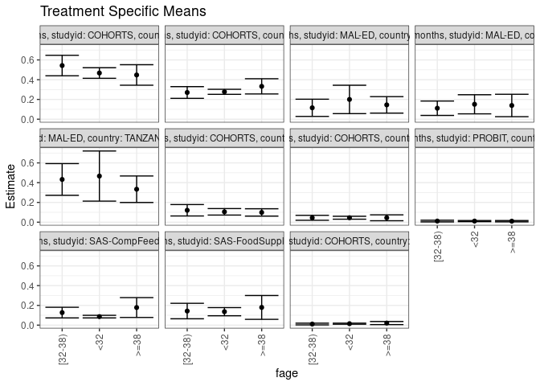

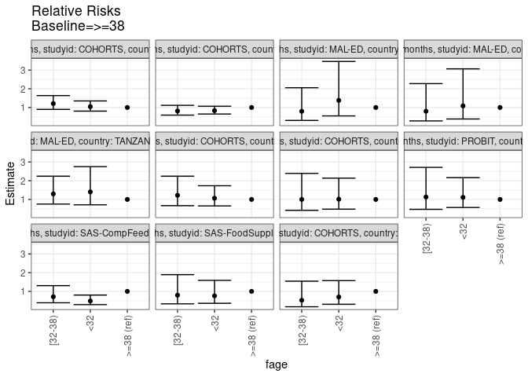

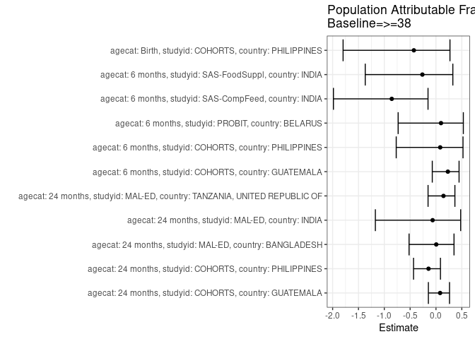

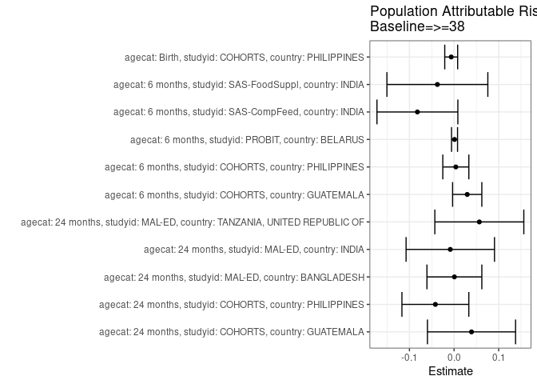

## Results Table

### Parameter: TSM

| agecat | studyid | country | intervention_level | baseline_level | estimate | ci_lower | ci_upper |
| --- | --- | --- | --- | --- | --- | --- | --- |
| Birth | COHORTS | PHILIPPINES | >=38 | NA | 0.0213415 | 0.0056987 | 0.0369842 |
| Birth | COHORTS | PHILIPPINES | <32 | NA | 0.0149110 | 0.0097004 | 0.0201216 |
| Birth | COHORTS | PHILIPPINES | [32-38) | NA | 0.0111732 | 0.0022815 | 0.0200649 |
| 6 months | COHORTS | GUATEMALA | >=38 | NA | 0.0985941 | 0.0613781 | 0.1358102 |
| 6 months | COHORTS | GUATEMALA | <32 | NA | 0.1048481 | 0.0721712 | 0.1375251 |
| 6 months | COHORTS | GUATEMALA | [32-38) | NA | 0.1204969 | 0.0627352 | 0.1782587 |
| 6 months | COHORTS | PHILIPPINES | >=38 | NA | 0.0444452 | 0.0146024 | 0.0742881 |
| 6 months | COHORTS | PHILIPPINES | <32 | NA | 0.0450195 | 0.0302959 | 0.0597431 |
| 6 months | COHORTS | PHILIPPINES | [32-38) | NA | 0.0443940 | 0.0195521 | 0.0692359 |
| 6 months | PROBIT | BELARUS | >=38 | NA | 0.0099857 | 0.0033820 | 0.0165895 |
| 6 months | PROBIT | BELARUS | <32 | NA | 0.0110883 | 0.0054005 | 0.0167761 |
| 6 months | PROBIT | BELARUS | [32-38) | NA | 0.0112749 | 0.0028915 | 0.0196584 |
| 6 months | SAS-CompFeed | INDIA | >=38 | NA | 0.1781928 | 0.0778188 | 0.2785669 |
| 6 months | SAS-CompFeed | INDIA | <32 | NA | 0.0863492 | 0.0732944 | 0.0994039 |
| 6 months | SAS-CompFeed | INDIA | [32-38) | NA | 0.1271328 | 0.0732959 | 0.1809698 |
| 6 months | SAS-FoodSuppl | INDIA | >=38 | NA | 0.1794872 | 0.0588872 | 0.3000872 |
| 6 months | SAS-FoodSuppl | INDIA | <32 | NA | 0.1363636 | 0.0949128 | 0.1778145 |
| 6 months | SAS-FoodSuppl | INDIA | [32-38) | NA | 0.1428571 | 0.0645949 | 0.2211194 |
| 24 months | COHORTS | GUATEMALA | >=38 | NA | 0.4476579 | 0.3438163 | 0.5514994 |
| 24 months | COHORTS | GUATEMALA | <32 | NA | 0.4674845 | 0.4138570 | 0.5211119 |
| 24 months | COHORTS | GUATEMALA | [32-38) | NA | 0.5429679 | 0.4393318 | 0.6466040 |
| 24 months | COHORTS | PHILIPPINES | >=38 | NA | 0.3324914 | 0.2554845 | 0.4094984 |
| 24 months | COHORTS | PHILIPPINES | <32 | NA | 0.2772188 | 0.2515670 | 0.3028706 |
| 24 months | COHORTS | PHILIPPINES | [32-38) | NA | 0.2702754 | 0.2110121 | 0.3295387 |
| 24 months | MAL-ED | BANGLADESH | >=38 | NA | 0.1449275 | 0.0615895 | 0.2282656 |
| 24 months | MAL-ED | BANGLADESH | <32 | NA | 0.2000000 | 0.0563881 | 0.3436119 |
| 24 months | MAL-ED | BANGLADESH | [32-38) | NA | 0.1153846 | 0.0282601 | 0.2025091 |
| 24 months | MAL-ED | INDIA | >=38 | NA | 0.1388889 | 0.0255672 | 0.2522106 |
| 24 months | MAL-ED | INDIA | <32 | NA | 0.1509434 | 0.0542630 | 0.2476238 |
| 24 months | MAL-ED | INDIA | [32-38) | NA | 0.1111111 | 0.0382934 | 0.1839289 |
| 24 months | MAL-ED | TANZANIA, UNITED REPUBLIC OF | >=38 | NA | 0.3333333 | 0.1993028 | 0.4673638 |
| 24 months | MAL-ED | TANZANIA, UNITED REPUBLIC OF | <32 | NA | 0.4666667 | 0.2129274 | 0.7204059 |
| 24 months | MAL-ED | TANZANIA, UNITED REPUBLIC OF | [32-38) | NA | 0.4324324 | 0.2719980 | 0.5928669 |

### Parameter: E(Y)

| agecat | studyid | country | intervention_level | baseline_level | estimate | ci_lower | ci_upper |
| --- | --- | --- | --- | --- | --- | --- | --- |
| Birth | COHORTS | PHILIPPINES | NA | NA | 0.0149457 | 0.0105620 | 0.0193293 |
| 6 months | COHORTS | GUATEMALA | NA | NA | 0.1280947 | 0.1065929 | 0.1495965 |
| 6 months | COHORTS | PHILIPPINES | NA | NA | 0.0483994 | 0.0401865 | 0.0566123 |
| 6 months | PROBIT | BELARUS | NA | NA | 0.0110657 | 0.0053836 | 0.0167479 |
| 6 months | SAS-CompFeed | INDIA | NA | NA | 0.0960240 | 0.0777684 | 0.1142796 |
| 6 months | SAS-FoodSuppl | INDIA | NA | NA | 0.1421053 | 0.1069532 | 0.1772573 |
| 24 months | COHORTS | GUATEMALA | NA | NA | 0.4867777 | 0.4561040 | 0.5174514 |
| 24 months | COHORTS | PHILIPPINES | NA | NA | 0.2905947 | 0.2723152 | 0.3088742 |
| 24 months | MAL-ED | BANGLADESH | NA | NA | 0.1456954 | 0.0892366 | 0.2021542 |
| 24 months | MAL-ED | INDIA | NA | NA | 0.1304348 | 0.0782510 | 0.1826186 |
| 24 months | MAL-ED | TANZANIA, UNITED REPUBLIC OF | NA | NA | 0.3900000 | 0.2939212 | 0.4860788 |

### Parameter: RR

| agecat | studyid | country | intervention_level | baseline_level | estimate | ci_lower | ci_upper |
| --- | --- | --- | --- | --- | --- | --- | --- |
| Birth | COHORTS | PHILIPPINES | >=38 | >=38 | 1.0000000 | 1.0000000 | 1.0000000 |
| Birth | COHORTS | PHILIPPINES | <32 | >=38 | 0.6986876 | 0.3101923 | 1.5737474 |
| Birth | COHORTS | PHILIPPINES | [32-38) | >=38 | 0.5235435 | 0.1774516 | 1.5446338 |
| 6 months | COHORTS | GUATEMALA | >=38 | >=38 | 1.0000000 | 1.0000000 | 1.0000000 |
| 6 months | COHORTS | GUATEMALA | <32 | >=38 | 1.0634321 | 0.6533481 | 1.7309115 |
| 6 months | COHORTS | GUATEMALA | [32-38) | >=38 | 1.2221514 | 0.6660911 | 2.2424171 |
| 6 months | COHORTS | PHILIPPINES | >=38 | >=38 | 1.0000000 | 1.0000000 | 1.0000000 |
| 6 months | COHORTS | PHILIPPINES | <32 | >=38 | 1.0129205 | 0.4802260 | 2.1365109 |
| 6 months | COHORTS | PHILIPPINES | [32-38) | >=38 | 0.9988471 | 0.4170323 | 2.3923697 |
| 6 months | PROBIT | BELARUS | >=38 | >=38 | 1.0000000 | 1.0000000 | 1.0000000 |
| 6 months | PROBIT | BELARUS | <32 | >=38 | 1.1104136 | 0.5699285 | 2.1634616 |
| 6 months | PROBIT | BELARUS | [32-38) | >=38 | 1.1291042 | 0.4698573 | 2.7133267 |
| 6 months | SAS-CompFeed | INDIA | >=38 | >=38 | 1.0000000 | 1.0000000 | 1.0000000 |
| 6 months | SAS-CompFeed | INDIA | <32 | >=38 | 0.4845826 | 0.2925702 | 0.8026119 |
| 6 months | SAS-CompFeed | INDIA | [32-38) | >=38 | 0.7134565 | 0.3897241 | 1.3061036 |
| 6 months | SAS-FoodSuppl | INDIA | >=38 | >=38 | 1.0000000 | 1.0000000 | 1.0000000 |
| 6 months | SAS-FoodSuppl | INDIA | <32 | >=38 | 0.7597403 | 0.3633993 | 1.5883498 |
| 6 months | SAS-FoodSuppl | INDIA | [32-38) | >=38 | 0.7959184 | 0.3344716 | 1.8939907 |
| 24 months | COHORTS | GUATEMALA | >=38 | >=38 | 1.0000000 | 1.0000000 | 1.0000000 |
| 24 months | COHORTS | GUATEMALA | <32 | >=38 | 1.0442896 | 0.8071594 | 1.3510849 |
| 24 months | COHORTS | GUATEMALA | [32-38) | >=38 | 1.2129082 | 0.8987856 | 1.6368158 |
| 24 months | COHORTS | PHILIPPINES | >=38 | >=38 | 1.0000000 | 1.0000000 | 1.0000000 |
| 24 months | COHORTS | PHILIPPINES | <32 | >=38 | 0.8337623 | 0.6506563 | 1.0683974 |
| 24 months | COHORTS | PHILIPPINES | [32-38) | >=38 | 0.8128793 | 0.5918304 | 1.1164899 |
| 24 months | MAL-ED | BANGLADESH | >=38 | >=38 | 1.0000000 | 1.0000000 | 1.0000000 |
| 24 months | MAL-ED | BANGLADESH | <32 | >=38 | 1.3800000 | 0.5499947 | 3.4625789 |
| 24 months | MAL-ED | BANGLADESH | [32-38) | >=38 | 0.7961538 | 0.3081799 | 2.0567884 |
| 24 months | MAL-ED | INDIA | >=38 | >=38 | 1.0000000 | 1.0000000 | 1.0000000 |
| 24 months | MAL-ED | INDIA | <32 | >=38 | 1.0867925 | 0.3851745 | 3.0664490 |
| 24 months | MAL-ED | INDIA | [32-38) | >=38 | 0.8000000 | 0.2809245 | 2.2781919 |
| 24 months | MAL-ED | TANZANIA, UNITED REPUBLIC OF | >=38 | >=38 | 1.0000000 | 1.0000000 | 1.0000000 |
| 24 months | MAL-ED | TANZANIA, UNITED REPUBLIC OF | <32 | >=38 | 1.4000000 | 0.7119272 | 2.7530904 |
| 24 months | MAL-ED | TANZANIA, UNITED REPUBLIC OF | [32-38) | >=38 | 1.2972973 | 0.7506467 | 2.2420404 |

### Parameter: PAR

| agecat | studyid | country | intervention_level | baseline_level | estimate | ci_lower | ci_upper |
| --- | --- | --- | --- | --- | --- | --- | --- |
| Birth | COHORTS | PHILIPPINES | >=38 | NA | -0.0063958 | -0.0208660 | 0.0080744 |
| 6 months | COHORTS | GUATEMALA | >=38 | NA | 0.0295006 | -0.0032644 | 0.0622656 |
| 6 months | COHORTS | PHILIPPINES | >=38 | NA | 0.0039541 | -0.0252298 | 0.0331381 |
| 6 months | PROBIT | BELARUS | >=38 | NA | 0.0010800 | -0.0056576 | 0.0078176 |
| 6 months | SAS-CompFeed | INDIA | >=38 | NA | -0.0821688 | -0.1728556 | 0.0085179 |
| 6 months | SAS-FoodSuppl | INDIA | >=38 | NA | -0.0373819 | -0.1504952 | 0.0757313 |
| 24 months | COHORTS | GUATEMALA | >=38 | NA | 0.0391198 | -0.0596591 | 0.1378987 |
| 24 months | COHORTS | PHILIPPINES | >=38 | NA | -0.0418968 | -0.1168900 | 0.0330965 |
| 24 months | MAL-ED | BANGLADESH | >=38 | NA | 0.0007678 | -0.0607588 | 0.0622945 |
| 24 months | MAL-ED | INDIA | >=38 | NA | -0.0084541 | -0.1075603 | 0.0906521 |
| 24 months | MAL-ED | TANZANIA, UNITED REPUBLIC OF | >=38 | NA | 0.0566667 | -0.0430816 | 0.1564149 |

### Parameter: PAF

| agecat | studyid | country | intervention_level | baseline_level | estimate | ci_lower | ci_upper |
| --- | --- | --- | --- | --- | --- | --- | --- |
| Birth | COHORTS | PHILIPPINES | >=38 | NA | -0.4279379 | -1.7976835 | 0.2711804 |
| 6 months | COHORTS | GUATEMALA | >=38 | NA | 0.2303031 | -0.0714133 | 0.4470543 |
| 6 months | COHORTS | PHILIPPINES | >=38 | NA | 0.0816983 | -0.7694564 | 0.5234253 |
| 6 months | PROBIT | BELARUS | >=38 | NA | 0.0975987 | -0.7318843 | 0.5298022 |
| 6 months | SAS-CompFeed | INDIA | >=38 | NA | -0.8557114 | -1.9845348 | -0.1538364 |
| 6 months | SAS-FoodSuppl | INDIA | >=38 | NA | -0.2630579 | -1.3691050 | 0.3266169 |
| 24 months | COHORTS | GUATEMALA | >=38 | NA | 0.0803648 | -0.1468565 | 0.2625679 |
| 24 months | COHORTS | PHILIPPINES | >=38 | NA | -0.1441759 | -0.4339808 | 0.0870599 |
| 24 months | MAL-ED | BANGLADESH | >=38 | NA | 0.0052701 | -0.5208155 | 0.3493704 |
| 24 months | MAL-ED | INDIA | >=38 | NA | -0.0648148 | -1.1729436 | 0.4782052 |
| 24 months | MAL-ED | TANZANIA, UNITED REPUBLIC OF | >=38 | NA | 0.1452991 | -0.1531681 | 0.3665160 |